# Lab4

Soyeon Lee

3/11/2021

1. Consider the following example data for a between-subjects experiment with two groups, A and B:

example_data <- tibble(Group = rep(c(“A”,“B”), each = 5), DV = c(2,4,3,5,4,7,6,5,6,7))

Use R to conduct a t.test and ANOVA on this data. Then use R to prove that the results of both analyses are the same. For example, prove that the p-values are the same, and prove that the F-value and T-value are related. (3 points) #Independence:90

```r
library(tibble)

example_data <- tibble(Group = rep(c("A","B"), each = 5),
                       DV = c(2,4,3,5,4,7,6,5,6,7))
#t-test
my_t<-t.test(DV~Group, var.equal=TRUE, data=example_data)
my_t
```

```
##
##  Two Sample t-test
##
## data:  DV by Group
## t = -4.111, df = 8, p-value = 0.003386
## alternative hypothesis: true difference in means is not equal to 0
## 95 percent confidence interval:
##  -4.058445 -1.141555
## sample estimates:
## mean in group A mean in group B
##             3.6             6.2
```

```r
#ANOVA
my_anova_summary<-summary(aov(DV~Group,data=example_data))

#Results of both analyses show that p-values are the same
##anova_p_value is a vector with two values
ttest_p_value<-my_t$p.value
anova_p_value<-my_anova_summary[[1]]$`Pr(>F)`[1]

round(ttest_p_value,5) == round(anova_p_value,5)
```

```
## [1] TRUE
```

```r
#Show that F and t statistics are related
t_squared<-my_t$statistic^2
F_value<-my_anova_summary[[1]]$`F value` [1]

round(t_squared,1)==round(F_value,1)
```

```
##    t
## TRUE
```

2. Look at the lab on ANOVA that I wrote for our undergraduate statistics OER lab manual https://crumplab.github.io/statisticsLab/lab-8-one-way-anova.html. That lab shows an example of obtaining data from a published paper in psych science where a one-factor ANOVA was used as a part of the analysis. Load the data, conduct the ANOVA, report a ggplot of the means, and use papaja to help you write a short results section reporting the ANOVA result. (3 points). Independence: 80

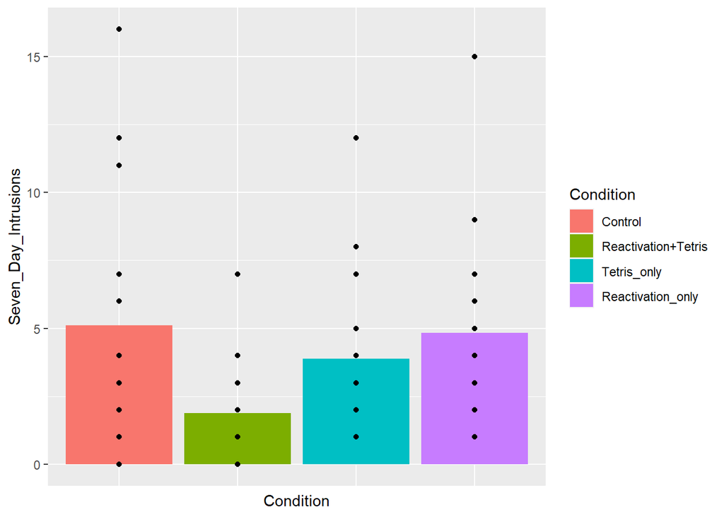

```r
#load the data
library(data.table)
all_data<-fread("data/Jamesetal2015Experiment2.csv")

#Conduct the ANOVA
##rename the levels with code from statisticsLab/lab-8
all_data$Condition<-as.factor(all_data$Condition)
levels(all_data$Condition)<-c("Control",
                              "Reactivation+Tetris",
                              "Tetris_only",
                              "Reactivation_only")
##Shorten the DV name "Days_One_to_Seven_Number_of_Intrusions"
names(all_data)[names(all_data)=="Days_One_to_Seven_Number_of_Intrusions"]<-"Seven_Day_Intrusions"

#ggplot of the means
##means calculated using the fun="mean"
library(ggplot2)
ggplot(all_data,aes(x=Condition,y=Seven_Day_Intrusions))+
  geom_bar(stat="summary",
           fun="mean",
           position="dodge",
           aes(fill=Condition))+
  geom_point()+
  theme(axis.text.x=element_blank(),
        axis.ticks.x=element_blank())
```

```r
##use anova function for the analysis
anova.out<-aov(Seven_Day_Intrusions~Condition,data=all_data)
summary(anova.out)
```

```
##             Df Sum Sq Mean Sq F value Pr(>F)
## Condition    3  114.8   38.27   3.795 0.0141 *
## Residuals   68  685.8   10.09
## ---
## Signif. codes:  0 '***' 0.001 '**' 0.01 '*' 0.05 '.' 0.1 ' ' 1
```

```r
#use papaja to report the result
library(papaja)
apa_print(anova.out)
```

```
## $estimate
## $estimate$Condition
## [1] "$\\hat{\\eta}^2_G = .143$"
##
##
## $statistic
## $statistic$Condition
## [1] "$F(3, 68) = 3.79$, $\\mathit{MSE} = 10.09$, $p = .014$"
##
##
## $full_result
## $full_result$Condition
## [1] "$F(3, 68) = 3.79$, $\\mathit{MSE} = 10.09$, $p = .014$, $\\hat{\\eta}^2_G = .143$"
##
##
## $table
## A data.frame with 7 labelled columns:
##
##      Effect    F df1 df2   MSE    p  ges
## 1 Condition 3.79   3  68 10.09 .014 .143
##
## Effect: Effect
## F     : $F$
## df1   : $\mathit{df}_1$
## df2   : $\mathit{df}_2$
## MSE   : $\mathit{MSE}$
## ... (2 more labels)
## attr(,"class")
## [1] "apa_results" "list"
```

#APA style report The one-factor between-subjects ANOVA revealed that intervention type (No-task control,Reactivation Plus tetris, Tetris only, Reactivation only) influences the number of intrusive memories, $F(3, 68) = 3.79$, $\mathit{MSE} = 10.09$, $p = .014$, $\hat{\eta}^2_G = .143$.